# Metodos de Gran Escala

Eduardo Hidalgo

Marzo 2018

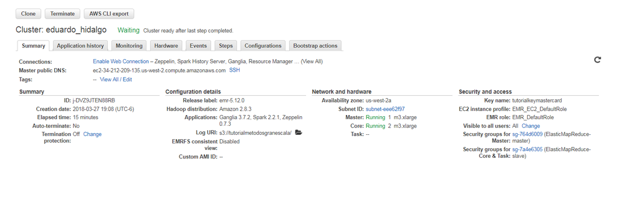

Cluster AWS.

## Tarea 5

### Pregunta 1

#### a.1) ¿Cuántos “jefes” hay en la tabla empleados?

```sql
SELECT COUNT(DISTINCT reportsto) as cantidad_jefes
FROM employees
WHERE reportsto > 0;
```

| cantidad_jefes |
| --- |
| 2 |

#### a.2) ¿Cuáles son estos jefes: número de empleado, nombre, apellido, título, fecha de nacimiento, fecha en que iniciaron en la empresa, ciudad y país? (atributo reportsto, ocupa explode en tu respuesta)

```sql
CREATE TEMPORARY TABLE tabla_1 as
SELECT reportsto, collect_list(firstname) as trabajadores
FROM employees
WHERE reportsto <> ''
GROUP BY reportsto;

CREATE TEMPORARY TABLE tabla_2 AS
SELECT emp.employeeid, emp.firstname, emp.lastname, emp.title, emp.hierdate, emp.city, emp.country, trabajadores
FROM employees emp
JOIN collect ON emp.employeeid=collect.reportsto;

SELECT employeeid, firstname, lastname, title, hiredate,city,country,empleado
FROM tabla_2
LATERAL VIEW explode(trabajadores) subView AS trabajador;
```

Resultado 2: Informacion de jefes

| employeeid | firstname | lastname | title | hiredate | city | country | empleado |
| --- | --- | --- | --- | --- | --- | --- | --- |
| 2 | Andrew | Fuller | Vice President, Sales | 8/14/1992 | Tacoma | USA | Nancy |
| 2 | Andrew | Fuller | Vice President, Sales | 8/14/1992 | Tacoma | USA | Janet |
| 2 | Andrew | Fuller | Vice President, Sales | 8/14/1992 | Tacoma | USA | Margaret |
| 2 | Andrew | Fuller | Vice President, Sales | 8/14/1992 | Tacoma | USA | Steven |
| 2 | Andrew | Fuller | Vice President, Sales | 8/14/1992 | Tacoma | USA | Laura |
| 5 | Steven | Buchanan | Sales Manager | 10/17/1993 | London | UK | Michael |
| 5 | Steven | Buchanan | Sales Manager | 10/17/1993 | London | UK | Robert |
| 5 | Steven | Buchanan | Sales Manager | 10/17/1993 | London | UK | Anne |

#### b) ¿Quién es el segundo “mejor” empleado que más órdenes ha generado? (nombre, apellido, título, cuándo entró a la compañía, número de órdenes generadas, número de órdenes generadas por el mejor empleado (número 1))

```sql
SELECT res.firstname, res.lastname, res.title, res.hiredate, res.cant, LEAD(cantidad) OVER(ORDER BY cant) maximo
FROM( SELECT emp.firstname, emp.lastname, emp.title, emp.hiredate,
count(*) as cantidad
FROM northwind.orders orders
JOIN  northwind.employees emp on orders.employeeid=emp.employeeid
GROUP BY emp.firstname, emp.lastname,emp.title,emp.hiredate
ORDER BY cantidad DESC
LIMIT 2 ) res
LIMIT 1;
```

Resultado 3: Informacion del segundo mejor

| res.firstname | res.lastname | res.title | res.hiredate | res.cant | maximo |
| --- | --- | --- | --- | --- | --- |
| Janet | Leverling | Sales Representative | 4/1/1992 | 127 | 156 |

#### c) ¿Cuál es el delta de tiempo más grande entre una orden y otra?

```sql
SELECT res.delta as tiempo_maximo
FROM( SELECT orderid, from_utc_timestamp(date_format(orderdate,'yyyy-mm-dd'),'UTC') fecha_pedido, datediff(orderdate,from_utc_timestamp(date_format(lag(orderdate) OVER(ORDER BY orderid),'yyyy-mm-dd'),'UTC')) delta
FROM orders
ORDER BY delta DESC) res
LIMIT 1;
```

| tiempo_maximo |
| --- |
| 3 |

### Pregunta 2

#### a) ¿Qué aerolíneas (nombres) llegan al aeropuerto “Honolulu International Airport”?

```sql
SELECT DISTINCT airlines.airline
FROM vuelos
JOIN airports ON vuelos.destination_airport=airports.iata_code
JOIN airlines ON vuelos.airline=airlines.iata_code
WHERE airlines.airport="Honolulu International Airport";
```

| airlines.airline |
| --- |
| Alaska Airlines Inc. |
| Hawaiian Airlines Inc. |
| United Air Lines Inc. |
| Virgin America |
| American Airlines Inc. |
| Delta Air Lines Inc. |
| US Airways Inc |

```sql
SELECT DISTINCT SUBSTR(vuelos.scheduled_departure,0,2) as hora
FROM vuelos
JOIN airports portsorig ON vuelos.origin_airport = portsorig.iata_code
JOIN airports portsdest ON vuelos.destination_airport=portsdest.iata_code
WHERE portsorig.airport="Honolulu International Airport" AND portsdest.airport="San Francisco International Airport";
```

| hora |
| --- |
| 6 |
| 7 |
| 11 |
| 16 |
| 20 |
| 0 |
| 22 |
| 23 |
| 12 |
| 13 |
| 14 |
| 15 |
| 21 |

#### c) ¿Qué día de la semana y en qué aerolínea nos conviene viajar a “Honolulu International Airport” para tener el menor retraso posible?

Para responder a esta pregunta se presenta el promedio del tiempo de retraso agrupado a nivel día, la recomendación es viajar el día de la semana cuyo promedio de retraso es el menor.

```sql
SELECT vuelos.day_of_week, vuelos.airline,lines.airline, AVG(vuelos.departure_delay) as retraso
FROM vuelos
JOIN airlines ON vuelos.airline=airlines.iata_code
JOIN airports ON vuelos.destination_airport=airports.iata_code
WHERE airports.airport="Honolulu International Airport" AND vuelos.departure_delay>0
GROUP BY vuelos.day_of_week,vuelos.airline,airlines.airline
ORDER BY delay ASC
LIMIT 1;
```

Resultado 7: Recomendación de vuelo a Honolulu Intl

| vuelos.day_of_week | vuelos.airline | airlines.airline | delay |
| --- | --- | --- | --- |
| 1 | VX | Virgin America | 3.875 |

#### d) ¿Cuál es el aeropuerto con mayor tráfico de entrada?

```sql
SELECT airports.airport, count(*) as trafico
FROM vuelos
JOIN airports ON vuelos.destination_airport = airports.iata_code
GROUP BY airports.airport
ORDER BY trafico DESC
LIMIT 1;
```

Resultado 8: Aeropuerto con mas trafico de entrada

| airports.airport | trafico |
| --- | --- |
| Hartsfield-Jackson Atlanta International Airport | 346904 |

#### e) ¿Cuál es la aerolínea con mayor retraso de salida por día de la semana?

```sql
SELECT aux.day_of_week,aux.maximo,vuelos_2.airline,airlines.airline
FROM (SELECT vuelos.day_of_week,MAX(departure_delay) as maximo_retraso
FROM vuelos
GROUP BY
vuelos.day_of_week) auxiliar
LEFT JOIN vuelos vuelos_2 ON vuelos_2.day_of_week=auxiliar.day_of_week AND vuelos_2.departure_delay=auxiliar.maximo_retraso
JOIN airlines ON vuelos_2.airline=airlines.iata_code
ORDER BY auxiliar.day_of_week;
```

Resultado 9: Aerolineas con mayor atraso por dia

| auxiliar.day_of_week | auxiliar.maximo | vuelos_2.airline | airlines.airline |
| --- | --- | --- | --- |
| 1 | 1625 | AA | American Airlines Inc. |
| 2 | 1609 | AA | American Airlines Inc. |
| 3 | 1589 | AA | American Airlines Inc. |
| 4 | 1649 | AA | American Airlines Inc. |
| 5 | 1988 | AA | American Airlines Inc. |
| 6 | 1878 | AA | American Airlines Inc. |
| 7 | 1670 | AA | American Airlines Inc. |

```sql
SELECT vuelos.origin_airport, airports.airport,count(DISTINCT vuelos.destination_airport) as destinos
FROM vuelos
JOIN airports ON vuelos.origin_airport=airports.iata_code
GROUP BY vuelos.origin_airport, airport.airport
ORDER BY destinos DESC
LIMIT 1;
```

[output not shown]